# Risk Factor Analysis

## Outcome Variable

**Outcome Variable:** haz

## Predictor Variables

**Intervention Variable:** nchldlt5

**Adjustment Set:**

unadjusted

## Stratifying Variables

The analysis was stratified on these variable(s):

- agecat
- studyid
- country

## Data Summary

| agecat | studyid | country | nchldlt5 | n_cell | n |
| --- | --- | --- | --- | --- | --- |
| Birth | IRC | INDIA | 1 | 84 | 388 |
| Birth | IRC | INDIA | 2+ | 304 | 388 |
| Birth | JiVitA-3 | BANGLADESH | 1 | 13986 | 22431 |
| Birth | JiVitA-3 | BANGLADESH | 2+ | 8445 | 22431 |
| Birth | NIH-Crypto | BANGLADESH | 1 | 522 | 732 |
| Birth | NIH-Crypto | BANGLADESH | 2+ | 210 | 732 |
| Birth | PROVIDE | BANGLADESH | 1 | 391 | 539 |
| Birth | PROVIDE | BANGLADESH | 2+ | 148 | 539 |
| 6 months | IRC | INDIA | 1 | 89 | 407 |
| 6 months | IRC | INDIA | 2+ | 318 | 407 |
| 6 months | JiVitA-3 | BANGLADESH | 1 | 10887 | 16800 |
| 6 months | JiVitA-3 | BANGLADESH | 2+ | 5913 | 16800 |
| 6 months | LCNI-5 | MALAWI | 1 | 390 | 811 |
| 6 months | LCNI-5 | MALAWI | 2+ | 421 | 811 |
| 6 months | NIH-Crypto | BANGLADESH | 1 | 507 | 715 |
| 6 months | NIH-Crypto | BANGLADESH | 2+ | 208 | 715 |
| 6 months | PROVIDE | BANGLADESH | 1 | 438 | 604 |
| 6 months | PROVIDE | BANGLADESH | 2+ | 166 | 604 |
| 6 months | TanzaniaChild2 | TANZANIA, UNITED REPUBLIC OF | 1 | 1391 | 2020 |
| 6 months | TanzaniaChild2 | TANZANIA, UNITED REPUBLIC OF | 2+ | 629 | 2020 |
| 24 months | IRC | INDIA | 1 | 89 | 409 |
| 24 months | IRC | INDIA | 2+ | 320 | 409 |
| 24 months | JiVitA-3 | BANGLADESH | 1 | 5454 | 8622 |
| 24 months | JiVitA-3 | BANGLADESH | 2+ | 3168 | 8622 |
| 24 months | LCNI-5 | MALAWI | 1 | 283 | 571 |
| 24 months | LCNI-5 | MALAWI | 2+ | 288 | 571 |
| 24 months | NIH-Crypto | BANGLADESH | 1 | 357 | 514 |
| 24 months | NIH-Crypto | BANGLADESH | 2+ | 157 | 514 |
| 24 months | PROVIDE | BANGLADESH | 1 | 424 | 578 |
| 24 months | PROVIDE | BANGLADESH | 2+ | 154 | 578 |
| 24 months | TanzaniaChild2 | TANZANIA, UNITED REPUBLIC OF | 1 | 5 | 6 |
| 24 months | TanzaniaChild2 | TANZANIA, UNITED REPUBLIC OF | 2+ | 1 | 6 |

The following strata were considered:

- agecat: 24 months, studyid: IRC, country: INDIA
- agecat: 24 months, studyid: JiVitA-3, country: BANGLADESH
- agecat: 24 months, studyid: LCNI-5, country: MALAWI
- agecat: 24 months, studyid: NIH-Crypto, country: BANGLADESH
- agecat: 24 months, studyid: PROVIDE, country: BANGLADESH
- agecat: 24 months, studyid: TanzaniaChild2, country: TANZANIA, UNITED REPUBLIC OF
- agecat: 6 months, studyid: IRC, country: INDIA
- agecat: 6 months, studyid: JiVitA-3, country: BANGLADESH
- agecat: 6 months, studyid: LCNI-5, country: MALAWI
- agecat: 6 months, studyid: NIH-Crypto, country: BANGLADESH
- agecat: 6 months, studyid: PROVIDE, country: BANGLADESH
- agecat: 6 months, studyid: TanzaniaChild2, country: TANZANIA, UNITED REPUBLIC OF
- agecat: Birth, studyid: IRC, country: INDIA
- agecat: Birth, studyid: JiVitA-3, country: BANGLADESH
- agecat: Birth, studyid: NIH-Crypto, country: BANGLADESH
- agecat: Birth, studyid: PROVIDE, country: BANGLADESH

### Dropped Strata

Some strata were dropped due to rare outcomes:

- agecat: 24 months, studyid: TanzaniaChild2, country: TANZANIA, UNITED REPUBLIC OF

## Methods Detail

We’re interested in the causal parameters $E[Y_a]$ for all values of $a \in \mathcal{A}$. These parameters represent the mean outcome if, possibly contrary to fact, we intervened to set all units to have $A=a$. Under the randomization and positivity assumptions, these are identified by the statistical parameters $\psi_a=E_W[E_{Y|A,W}(Y|A=a,W)]$. In addition, we’re interested in the mean of $Y$, $E[Y]$ under no intervention (the observed mean). We will estimate these parameters by using SuperLearner to fit the relevant likelihood factors – $E_{Y|A,W}(Y|A=a,W)$ and $p(A=a|W)$, and then updating our likelihood fit using a joint TMLE.

For unadjusted analyses ($W=\{\}$), initial likelihoods were estimated using Lrnr_glm to estimate the simple $E(Y|A)$ and Lrnr_mean to estimate $p(A)$. For adjusted analyses, a small library containing Lrnr_glmnet, Lrnr_xgboost, and Lrnr_mean was used.

Having estimated these parameters, we will then use the delta method to estimate relative risks and attributable risks relative to a prespecified baseline level of $A$.

# Results Detail

## Results Plots

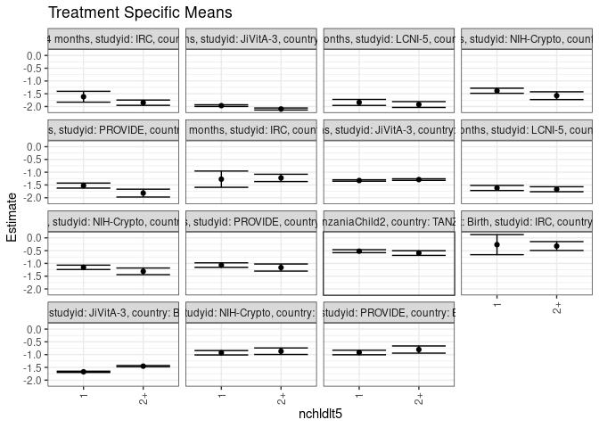

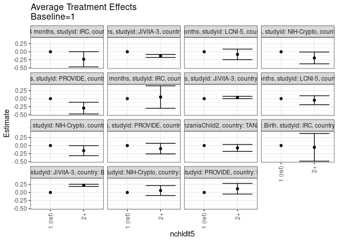

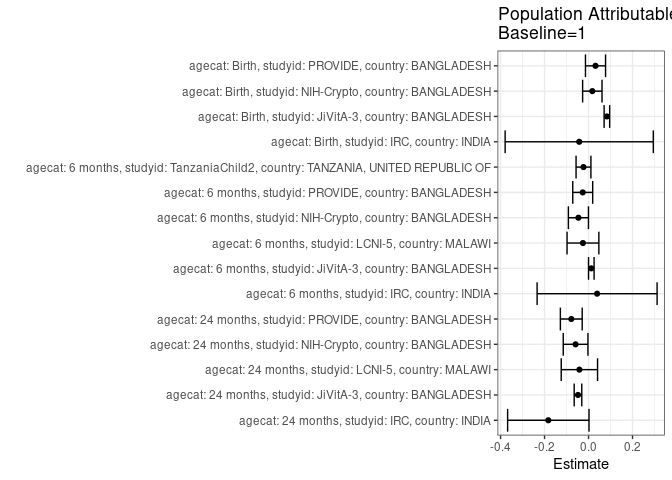

## Results Table

### Parameter: TSM

| agecat | studyid | country | intervention_level | baseline_level | estimate | ci_lower | ci_upper |
| --- | --- | --- | --- | --- | --- | --- | --- |
| Birth | IRC | INDIA | 1 | NA | -0.2657143 | -0.6588889 | 0.1274604 |
| Birth | IRC | INDIA | 2+ | NA | -0.3197368 | -0.4937600 | -0.1457137 |
| Birth | JiVitA-3 | BANGLADESH | 1 | NA | -1.6731539 | -1.6975455 | -1.6487623 |
| Birth | JiVitA-3 | BANGLADESH | 2+ | NA | -1.4514979 | -1.4777489 | -1.4252470 |
| Birth | NIH-Crypto | BANGLADESH | 1 | NA | -0.9267050 | -1.0128035 | -0.8406065 |
| Birth | NIH-Crypto | BANGLADESH | 2+ | NA | -0.8667143 | -0.9938559 | -0.7395727 |
| Birth | PROVIDE | BANGLADESH | 1 | NA | -0.9168286 | -1.0055126 | -0.8281447 |
| Birth | PROVIDE | BANGLADESH | 2+ | NA | -0.8012838 | -0.9410093 | -0.6615583 |
| 6 months | IRC | INDIA | 1 | NA | -1.2733708 | -1.5919940 | -0.9547475 |
| 6 months | IRC | INDIA | 2+ | NA | -1.2235010 | -1.3661342 | -1.0808679 |
| 6 months | JiVitA-3 | BANGLADESH | 1 | NA | -1.3257371 | -1.3531201 | -1.2983542 |
| 6 months | JiVitA-3 | BANGLADESH | 2+ | NA | -1.2899391 | -1.3211854 | -1.2586928 |
| 6 months | LCNI-5 | MALAWI | 1 | NA | -1.6177692 | -1.7171795 | -1.5183589 |
| 6 months | LCNI-5 | MALAWI | 2+ | NA | -1.6666746 | -1.7642591 | -1.5690901 |
| 6 months | NIH-Crypto | BANGLADESH | 1 | NA | -1.1526824 | -1.2376257 | -1.0677392 |
| 6 months | NIH-Crypto | BANGLADESH | 2+ | NA | -1.3107933 | -1.4414389 | -1.1801476 |
| 6 months | PROVIDE | BANGLADESH | 1 | NA | -1.0652321 | -1.1532155 | -0.9772487 |
| 6 months | PROVIDE | BANGLADESH | 2+ | NA | -1.1615060 | -1.3003786 | -1.0226335 |
| 6 months | TanzaniaChild2 | TANZANIA, UNITED REPUBLIC OF | 1 | NA | -0.5212527 | -0.5791074 | -0.4633980 |
| 6 months | TanzaniaChild2 | TANZANIA, UNITED REPUBLIC OF | 2+ | NA | -0.5950212 | -0.6865883 | -0.5034541 |
| 24 months | IRC | INDIA | 1 | NA | -1.6158989 | -1.8282244 | -1.4035733 |
| 24 months | IRC | INDIA | 2+ | NA | -1.8496406 | -1.9530130 | -1.7462683 |
| 24 months | JiVitA-3 | BANGLADESH | 1 | NA | -1.9654620 | -1.9986073 | -1.9323168 |
| 24 months | JiVitA-3 | BANGLADESH | 2+ | NA | -2.0960069 | -2.1356405 | -2.0563734 |
| 24 months | LCNI-5 | MALAWI | 1 | NA | -1.8390989 | -1.9570993 | -1.7210985 |
| 24 months | LCNI-5 | MALAWI | 2+ | NA | -1.9215451 | -2.0348805 | -1.8082098 |
| 24 months | NIH-Crypto | BANGLADESH | 1 | NA | -1.3824090 | -1.4818437 | -1.2829742 |
| 24 months | NIH-Crypto | BANGLADESH | 2+ | NA | -1.5750955 | -1.7275640 | -1.4226271 |
| 24 months | PROVIDE | BANGLADESH | 1 | NA | -1.5240094 | -1.6219120 | -1.4261069 |
| 24 months | PROVIDE | BANGLADESH | 2+ | NA | -1.8183117 | -1.9717687 | -1.6648547 |

### Parameter: E(Y)

| agecat | studyid | country | intervention_level | baseline_level | estimate | ci_lower | ci_upper |
| --- | --- | --- | --- | --- | --- | --- | --- |
| Birth | IRC | INDIA | NA | NA | -0.3080412 | -0.4687931 | -0.1472894 |
| Birth | JiVitA-3 | BANGLADESH | NA | NA | -1.5897031 | -1.6089786 | -1.5704276 |
| Birth | NIH-Crypto | BANGLADESH | NA | NA | -0.9094945 | -0.9809370 | -0.8380521 |
| Birth | PROVIDE | BANGLADESH | NA | NA | -0.8851020 | -0.9601332 | -0.8100709 |
| 6 months | IRC | INDIA | NA | NA | -1.2344062 | -1.3658524 | -1.1029600 |
| 6 months | JiVitA-3 | BANGLADESH | NA | NA | -1.3131375 | -1.3362767 | -1.2899983 |
| 6 months | LCNI-5 | MALAWI | NA | NA | -1.6431566 | -1.7128296 | -1.5734836 |
| 6 months | NIH-Crypto | BANGLADESH | NA | NA | -1.1986783 | -1.2700937 | -1.1272630 |
| 6 months | PROVIDE | BANGLADESH | NA | NA | -1.0916915 | -1.1661176 | -1.0172654 |
| 6 months | TanzaniaChild2 | TANZANIA, UNITED REPUBLIC OF | NA | NA | -0.5442232 | -0.5932373 | -0.4952090 |
| 24 months | IRC | INDIA | NA | NA | -1.7987775 | -1.8923914 | -1.7051636 |
| 24 months | JiVitA-3 | BANGLADESH | NA | NA | -2.0134284 | -2.0411019 | -1.9857549 |
| 24 months | LCNI-5 | MALAWI | NA | NA | -1.8806830 | -1.9625334 | -1.7988326 |
| 24 months | NIH-Crypto | BANGLADESH | NA | NA | -1.4412646 | -1.5249156 | -1.3576135 |
| 24 months | PROVIDE | BANGLADESH | NA | NA | -1.6024221 | -1.6857420 | -1.5191023 |

### Parameter: ATE

| agecat | studyid | country | intervention_level | baseline_level | estimate | ci_lower | ci_upper |
| --- | --- | --- | --- | --- | --- | --- | --- |
| Birth | IRC | INDIA | 1 | 1 | 0.0000000 | 0.0000000 | 0.0000000 |
| Birth | IRC | INDIA | 2+ | 1 | -0.0540226 | -0.4839881 | 0.3759430 |
| Birth | JiVitA-3 | BANGLADESH | 1 | 1 | 0.0000000 | 0.0000000 | 0.0000000 |
| Birth | JiVitA-3 | BANGLADESH | 2+ | 1 | 0.2216559 | 0.1882776 | 0.2550343 |
| Birth | NIH-Crypto | BANGLADESH | 1 | 1 | 0.0000000 | 0.0000000 | 0.0000000 |
| Birth | NIH-Crypto | BANGLADESH | 2+ | 1 | 0.0599907 | -0.0935604 | 0.2135418 |
| Birth | PROVIDE | BANGLADESH | 1 | 1 | 0.0000000 | 0.0000000 | 0.0000000 |
| Birth | PROVIDE | BANGLADESH | 2+ | 1 | 0.1155449 | -0.0499485 | 0.2810382 |
| 6 months | IRC | INDIA | 1 | 1 | 0.0000000 | 0.0000000 | 0.0000000 |
| 6 months | IRC | INDIA | 2+ | 1 | 0.0498697 | -0.2992219 | 0.3989614 |
| 6 months | JiVitA-3 | BANGLADESH | 1 | 1 | 0.0000000 | 0.0000000 | 0.0000000 |
| 6 months | JiVitA-3 | BANGLADESH | 2+ | 1 | 0.0357980 | 0.0000304 | 0.0715656 |
| 6 months | LCNI-5 | MALAWI | 1 | 1 | 0.0000000 | 0.0000000 | 0.0000000 |
| 6 months | LCNI-5 | MALAWI | 2+ | 1 | -0.0489054 | -0.1882077 | 0.0903970 |
| 6 months | NIH-Crypto | BANGLADESH | 1 | 1 | 0.0000000 | 0.0000000 | 0.0000000 |
| 6 months | NIH-Crypto | BANGLADESH | 2+ | 1 | -0.1581108 | -0.3139429 | -0.0022788 |
| 6 months | PROVIDE | BANGLADESH | 1 | 1 | 0.0000000 | 0.0000000 | 0.0000000 |
| 6 months | PROVIDE | BANGLADESH | 2+ | 1 | -0.0962739 | -0.2606718 | 0.0681240 |
| 6 months | TanzaniaChild2 | TANZANIA, UNITED REPUBLIC OF | 1 | 1 | 0.0000000 | 0.0000000 | 0.0000000 |
| 6 months | TanzaniaChild2 | TANZANIA, UNITED REPUBLIC OF | 2+ | 1 | -0.0737685 | -0.1820815 | 0.0345445 |
| 24 months | IRC | INDIA | 1 | 1 | 0.0000000 | 0.0000000 | 0.0000000 |
| 24 months | IRC | INDIA | 2+ | 1 | -0.2337417 | -0.4698942 | 0.0024107 |
| 24 months | JiVitA-3 | BANGLADESH | 1 | 1 | 0.0000000 | 0.0000000 | 0.0000000 |
| 24 months | JiVitA-3 | BANGLADESH | 2+ | 1 | -0.1305449 | -0.1776864 | -0.0834034 |
| 24 months | LCNI-5 | MALAWI | 1 | 1 | 0.0000000 | 0.0000000 | 0.0000000 |
| 24 months | LCNI-5 | MALAWI | 2+ | 1 | -0.0824462 | -0.2460585 | 0.0811662 |
| 24 months | NIH-Crypto | BANGLADESH | 1 | 1 | 0.0000000 | 0.0000000 | 0.0000000 |
| 24 months | NIH-Crypto | BANGLADESH | 2+ | 1 | -0.1926866 | -0.3747138 | -0.0106594 |
| 24 months | PROVIDE | BANGLADESH | 1 | 1 | 0.0000000 | 0.0000000 | 0.0000000 |
| 24 months | PROVIDE | BANGLADESH | 2+ | 1 | -0.2943023 | -0.4763296 | -0.1122749 |

### Parameter: PAR

| agecat | studyid | country | intervention_level | baseline_level | estimate | ci_lower | ci_upper |
| --- | --- | --- | --- | --- | --- | --- | --- |
| Birth | IRC | INDIA | 1 | NA | -0.0423270 | -0.3792145 | 0.2945606 |
| Birth | JiVitA-3 | BANGLADESH | 1 | NA | 0.0834508 | 0.0708382 | 0.0960633 |
| Birth | NIH-Crypto | BANGLADESH | 1 | NA | 0.0172104 | -0.0268850 | 0.0613059 |
| Birth | PROVIDE | BANGLADESH | 1 | NA | 0.0317266 | -0.0139234 | 0.0773766 |
| 6 months | IRC | INDIA | 1 | NA | 0.0389646 | -0.2337975 | 0.3117266 |
| 6 months | JiVitA-3 | BANGLADESH | 1 | NA | 0.0125996 | -0.0000234 | 0.0252226 |
| 6 months | LCNI-5 | MALAWI | 1 | NA | -0.0253874 | -0.0977205 | 0.0469458 |
| 6 months | NIH-Crypto | BANGLADESH | 1 | NA | -0.0459959 | -0.0916338 | -0.0003579 |
| 6 months | PROVIDE | BANGLADESH | 1 | NA | -0.0264594 | -0.0717716 | 0.0188529 |
| 6 months | TanzaniaChild2 | TANZANIA, UNITED REPUBLIC OF | 1 | NA | -0.0229705 | -0.0567305 | 0.0107896 |
| 24 months | IRC | INDIA | 1 | NA | -0.1828786 | -0.3678802 | 0.0021230 |
| 24 months | JiVitA-3 | BANGLADESH | 1 | NA | -0.0479664 | -0.0652124 | -0.0307203 |
| 24 months | LCNI-5 | MALAWI | 1 | NA | -0.0415841 | -0.1241759 | 0.0410078 |
| 24 months | NIH-Crypto | BANGLADESH | 1 | NA | -0.0588556 | -0.1149833 | -0.0027280 |
| 24 months | PROVIDE | BANGLADESH | 1 | NA | -0.0784127 | -0.1280597 | -0.0287657 |